# Airport Waiting Times

Jessi Kehe

This R Markdown document was adapted from documents created by Professor Bret Larget.

### Setup details

- You will need the packages `tidyverse`, `lubridate`, and `XML` for these lectures. Make sure to install them if you haven’t already.
- This assumes you have the R script `viridis.R` two steps back from the working directory (`"../../scripts/viridis.R"`). Be sure to adjust the code if you have this script in a different location.
- The following data files will be used and are assumed to be located two steps back from the working directory in a folder called `data/`. Be sure to adjust the code if you have the data files in a different location.  
  `"../../data/DEN-2018.html"`  
  `"../../data/JFK-2018.html"`  
  `"../../data/LAX-2018.html"`  
  `"../../data/MSP-2018.html"`  
  `"../../data/ORD-2018.html"`  
  `"../../data/SFO-2018.html"`

# Lecture: Importing the data files

## Airport Waiting Times

### Overview

- In the US, Customs and Border Patrol gathers statistics on the number of flights and passengers that go through customs at many US airports on an hourly basis.
- They also gather statistics on waiting times.
  - mean and maximum time
  - number of booths open
  - separate for domestic and international travelers

### Airports

- We will look at data from 2018 on several US Airports
  - DEN (Denver)
  - JFK (New York)
  - LAX (Los Angeles)
  - MSP (Minneapolis)
  - ORD (Chicago, O’Hare)
  - SFO (San Francisco)

### R commands

- XML package
  - `readHTMLTable()`
- dplyr package:
  - `bind_rows()`
  - `mutate_f()`
  - `mutate_at()`
- lubridate package:
  - `mdy()`

## Reading in an HTML Table

- The function `readHTMLTable()` in the `XML` package can read in tables from HTML files.
- However, it expects tables to have a single header row.
- When they do not, such as in this example, it takes more care.
- The function code below does a number of things to read in the data.
  - Grab part of a list as the data
  - Use `slice()` to get rid of the three header lines
  - Add new column names
  - Use `mutate_if()` and `mutate_at()` to change format of some variables
  - Use `mutate()` from `dplyr` and `mdy()` from `lubridate` to modify the date variable.

### Consider MSP for our test airport file

```r
### Let's look at the actual HTML file first, then try to read in the data
test_airport_file <- "../../data/MSP-2018.html" # specify airport file
```

#### Specify the column names that we want to use

```r
# Next we specify the column names
airport_column_names = c("airport",
                           "terminal",
                           "date",
                           "hour",
                           "us_avg_wait",
                           "us_max_wait",
                           "non_us_avg_wait",
                           "non_us_max_wait",
                           "all_avg_wait",
                           "all_max_wait",
                           "all_n_0_15",
                           "all_n_16_30",
                           "all_n_31_45",
                           "all_n_46_60",
                           "all_n_61_90",
                           "all_n_91_120",
                           "all_n_120_plus",
                           "all_excluded",
                           "all_total",
                           "all_flights",
                           "all_booths")
airport_column_names
```

```
##  [1] "airport"         "terminal"        "date"            "hour"
##  [5] "us_avg_wait"     "us_max_wait"     "non_us_avg_wait" "non_us_max_wait"
##  [9] "all_avg_wait"    "all_max_wait"    "all_n_0_15"      "all_n_16_30"
## [13] "all_n_31_45"     "all_n_46_60"     "all_n_61_90"     "all_n_91_120"
## [17] "all_n_120_plus"  "all_excluded"    "all_total"       "all_flights"
## [21] "all_booths"
```

#### Read in the data using readHTMLTable()

```r
test_airport <- readHTMLTable(test_airport_file)$`NULL` %>%
    slice(-(1:3)) # Remove the first three rows

names(test_airport) # default column names
```

```
##  [1] "V1"  "V2"  "V3"  "V4"  "V5"  "V6"  "V7"  "V8"  "V9"  "V10" "V11" "V12"
## [13] "V13" "V14" "V15" "V16" "V17" "V18" "V19" "V20" "V21"
```

```r
names(test_airport) <- airport_column_names # replace with new names
names(test_airport)
```

```
##  [1] "airport"         "terminal"        "date"            "hour"
##  [5] "us_avg_wait"     "us_max_wait"     "non_us_avg_wait" "non_us_max_wait"
##  [9] "all_avg_wait"    "all_max_wait"    "all_n_0_15"      "all_n_16_30"
## [13] "all_n_31_45"     "all_n_46_60"     "all_n_61_90"     "all_n_91_120"
## [17] "all_n_120_plus"  "all_excluded"    "all_total"       "all_flights"
## [21] "all_booths"
```

#### Make a Tibble and adjust structure

First look at the current structure - the variables are all set as characters.

```r
# Look at the data types for the different variables
str(test_airport)
```

```
## 'data.frame':    5793 obs. of  21 variables:
##  $ airport        : chr  "MSP" "MSP" "MSP" "MSP" ...
##  $ terminal       : chr  "Terminal 1Lindbergh" "Terminal 1Lindbergh" "Terminal 1Lindbergh" "Terminal 1Lindbergh" ...
##  $ date           : chr  "1/1/2018" "1/1/2018" "1/1/2018" "1/1/2018" ...
##  $ hour           : chr  "0800 - 0900" "1100 - 1200" "1200 - 1300" "1500 - 1600" ...
##  $ us_avg_wait    : chr  "6" "10" "16" "10" ...
##  $ us_max_wait    : chr  "12" "33" "49" "37" ...
##  $ non_us_avg_wait: chr  "6" "18" "30" "25" ...
##  $ non_us_max_wait: chr  "22" "34" "52" "52" ...
##  $ all_avg_wait   : chr  "6" "13" "19" "14" ...
##  $ all_max_wait   : chr  "22" "34" "52" "52" ...
##  $ all_n_0_15     : chr  "62" "158" "208" "312" ...
##  $ all_n_16_30    : chr  "3" "88" "239" "69" ...
##  $ all_n_31_45    : chr  "0" "16" "49" "42" ...
##  $ all_n_46_60    : chr  "0" "0" "27" "6" ...
##  $ all_n_61_90    : chr  "0" "0" "0" "0" ...
##  $ all_n_91_120   : chr  "0" "0" "0" "0" ...
##  $ all_n_120_plus : chr  "0" "0" "0" "0" ...
##  $ all_excluded   : chr  "2" "10" "23" "15" ...
##  $ all_total      : chr  "67" "272" "546" "444" ...
##  $ all_flights    : chr  "1" "1" "2" "2" ...
##  $ all_booths     : chr  "2" "8" "8" "6" ...
```

Adjust the data types as needed.

```r
test_airport <- test_airport %>%
    as_tibble() %>%
    mutate_at(.vars = vars(ends_with("wait"),starts_with("all")),
              .funs = as.numeric) %>% # Turn the wait times into numbers
    mutate_if(is.factor,as.character) %>% # If any variables are factors, convert to characters
    mutate(date = mdy(date)) # Set `date` as a Date format; specify form of data (month, day, year)
str(test_airport)
```

```
## tibble [5,793 × 21] (S3: tbl_df/tbl/data.frame)
##  $ airport        : chr [1:5793] "MSP" "MSP" "MSP" "MSP" ...
##  $ terminal       : chr [1:5793] "Terminal 1Lindbergh" "Terminal 1Lindbergh" "Terminal 1Lindbergh" "Terminal 1Lindbergh" ...
##  $ date           : Date[1:5793], format: "2018-01-01" "2018-01-01" ...
##  $ hour           : chr [1:5793] "0800 - 0900" "1100 - 1200" "1200 - 1300" "1500 - 1600" ...
##  $ us_avg_wait    : num [1:5793] 6 10 16 10 9 9 12 4 6 11 ...
##  $ us_max_wait    : num [1:5793] 12 33 49 37 16 30 23 10 13 22 ...
##  $ non_us_avg_wait: num [1:5793] 6 18 30 25 12 19 13 4 8 20 ...
##  $ non_us_max_wait: num [1:5793] 22 34 52 52 12 29 22 4 11 22 ...
##  $ all_avg_wait   : num [1:5793] 6 13 19 14 9 10 12 4 6 11 ...
##  $ all_max_wait   : num [1:5793] 22 34 52 52 16 30 23 10 13 22 ...
##  $ all_n_0_15     : num [1:5793] 62 158 208 312 148 241 99 22 22 112 ...
##  $ all_n_16_30    : num [1:5793] 3 88 239 69 1 71 55 0 0 48 ...
##  $ all_n_31_45    : num [1:5793] 0 16 49 42 0 0 0 0 0 0 ...
##  $ all_n_46_60    : num [1:5793] 0 0 27 6 0 0 0 0 0 0 ...
##  $ all_n_61_90    : num [1:5793] 0 0 0 0 0 0 0 0 0 0 ...
##  $ all_n_91_120   : num [1:5793] 0 0 0 0 0 0 0 0 0 0 ...
##  $ all_n_120_plus : num [1:5793] 0 0 0 0 0 0 0 0 0 0 ...
##  $ all_excluded   : num [1:5793] 2 10 23 15 6 7 3 1 2 5 ...
##  $ all_total      : num [1:5793] 67 272 546 444 155 319 157 23 24 165 ...
##  $ all_flights    : num [1:5793] 1 1 2 2 1 2 1 1 2 1 ...
##  $ all_booths     : num [1:5793] 2 8 8 6 2 4 4 0 0 3 ...
```

### Define function for reading in other files

We will do through the same steps as with our test airport for several different data files.  
To make the code cleaner, let’s define a function `read_airport()` that takes an HTML and carries out the same steps as above.

```r
read_airport <- function(x)
  # Input:  x = HTML file
  # Output: nicely formatted tibble
{
  airport_column_names <- c("airport",
                           "terminal",
                           "date",
                           "hour",
                           "us_avg_wait",
                           "us_max_wait",
                           "non_us_avg_wait",
                           "non_us_max_wait",
                           "all_avg_wait",
                           "all_max_wait",
                           "all_n_0_15",
                           "all_n_16_30",
                           "all_n_31_45",
                           "all_n_46_60",
                           "all_n_61_90",
                           "all_n_91_120",
                           "all_n_120_plus",
                           "all_excluded",
                           "all_total",
                           "all_flights",
                           "all_booths")

  airport <- readHTMLTable(x)$`NULL` %>%
    slice(-(1:3))

  names(airport) <- airport_column_names

  airport <- airport %>%
    as_tibble() %>%
    mutate_at(.vars = vars(ends_with("wait"),starts_with("all")),
              .funs = as.numeric) %>%
    mutate_if(is.factor,as.character) %>%
    mutate(date = mdy(date))

  return(airport)
}
```

## Read the Data

```r
den <- read_airport("../../data/DEN-2018.html")
jfk <- read_airport("../../data/JFK-2018.html")
lax <- read_airport("../../data/LAX-2018.html")
msp <- read_airport("../../data/MSP-2018.html")
ord <- read_airport("../../data/ORD-2018.html")
sfo <- read_airport("../../data/SFO-2018.html")
```

## Combine the data into one large data frame

```r
awt <- bind_rows(den,jfk,lax,msp, ord,sfo)
rm(den,jfk,lax,msp,ord,sfo)

str(awt)
```

```
## tibble [72,089 × 21] (S3: tbl_df/tbl/data.frame)
##  $ airport        : chr [1:72089] "DEN" "DEN" "DEN" "DEN" ...
##  $ terminal       : chr [1:72089] "International" "International" "International" "International" ...
##  $ date           : Date[1:72089], format: "2018-01-01" "2018-01-01" ...
##  $ hour           : chr [1:72089] "0800 - 0900" "1000 - 1100" "1100 - 1200" "1200 - 1300" ...
##  $ us_avg_wait    : num [1:72089] 24 13 16 6 32 22 23 18 29 10 ...
##  $ us_max_wait    : num [1:72089] 42 25 31 24 55 53 55 42 87 18 ...
##  $ non_us_avg_wait: num [1:72089] 28 15 16 13 34 23 25 14 37 12 ...
##  $ non_us_max_wait: num [1:72089] 42 25 31 26 55 55 53 41 85 17 ...
##  $ all_avg_wait   : num [1:72089] 25 14 16 9 33 23 23 17 30 10 ...
##  $ all_max_wait   : num [1:72089] 42 25 31 26 55 55 55 42 87 18 ...
##  $ all_n_0_15     : num [1:72089] 14 88 93 163 5 105 133 189 38 251 ...
##  $ all_n_16_30    : num [1:72089] 90 61 157 36 111 184 354 197 167 23 ...
##  $ all_n_31_45    : num [1:72089] 44 0 5 0 114 51 122 35 67 0 ...
##  $ all_n_46_60    : num [1:72089] 0 0 0 0 31 35 28 0 0 0 ...
##  $ all_n_61_90    : num [1:72089] 0 0 0 0 0 0 0 0 28 0 ...
##  $ all_n_91_120   : num [1:72089] 0 0 0 0 0 0 0 0 0 0 ...
##  $ all_n_120_plus : num [1:72089] 0 0 0 0 0 0 0 0 0 0 ...
##  $ all_excluded   : num [1:72089] 8 8 12 9 14 20 28 23 11 15 ...
##  $ all_total      : num [1:72089] 156 157 267 208 275 395 665 444 311 289 ...
##  $ all_flights    : num [1:72089] 1 1 2 1 1 2 3 3 3 2 ...
##  $ all_booths     : num [1:72089] 5 6 6 8 9 9 9 9 6 7 ...
```

# Lecture: Exploratory Data Analysis

### Any missing data?

```r
count_na <- function(x)
{
  return ( sum(is.na(x) ) )
}

awt %>%
  summarize_all(count_na)
```

```
## # A tibble: 1 x 21
##   airport terminal  date  hour us_avg_wait us_max_wait non_us_avg_wait
##     <int>    <int> <int> <int>       <int>       <int>           <int>
## 1       0        0     0     0           0           0               0
## # … with 14 more variables: non_us_max_wait <int>, all_avg_wait <int>,
## #   all_max_wait <int>, all_n_0_15 <int>, all_n_16_30 <int>, all_n_31_45 <int>,
## #   all_n_46_60 <int>, all_n_61_90 <int>, all_n_91_120 <int>,
## #   all_n_120_plus <int>, all_excluded <int>, all_total <int>,
## #   all_flights <int>, all_booths <int>
```

```r
# There are no missing values for any variables.
```

### Summarize Key Variables

```r
## airports and terminals
awt %>%
  group_by(airport,terminal) %>%
  summarize(passengers = sum(all_total),
            flights = sum(all_flights))
```

```
## # A tibble: 16 x 4
## # Groups:   airport [6]
##    airport terminal                           passengers flights
##    <chr>   <chr>                                   <dbl>   <dbl>
##  1 DEN     International                         1032579    5815
##  2 JFK     Terminal 1                            3863833   14522
##  3 JFK     Terminal 4 (IAT)                      6606351   32839
##  4 JFK     Terminal 5 (Jet Blue)                 1605432   10638
##  5 JFK     Terminal 7 (British)                  1750517    8536
##  6 JFK     Terminal 8 (American)                 1996535    9628
##  7 LAX     Satellite 2                            796057    6539
##  8 LAX     Satellite 5                              5357     527
##  9 LAX     Satellite 7                            770716    5958
## 10 LAX     Terminal 4                             353672    2925
## 11 LAX     Tom Bradley International Terminal    9801130   45055
## 12 MSP     Terminal 1Lindbergh                    757179    4533
## 13 MSP     Terminal 2Humphrey                     243953    4567
## 14 ORD     Terminal 5                            5601907   29529
## 15 SFO     Terminal A                            2744262   11975
## 16 SFO     Terminal G                            3501690   15480
```

```r
### JFK and LAX have five different international terminals
### The other airports have one or two each.
```

```r
## examine date by airport
awt %>%
  select(airport,date) %>%
  distinct() %>%
  group_by(airport) %>%
  summarize(n = n())
```

```
## # A tibble: 6 x 2
##   airport     n
##   <chr>   <int>
## 1 DEN       364
## 2 JFK       364
## 3 LAX       364
## 4 MSP       364
## 5 ORD       364
## 6 SFO       364
```

```r
## One date is missing for all the airports
```

```r
## Let's figure out which date is missing
awt <- awt %>%
  mutate(month = month(date, label=TRUE)) %>% # add a month variable
  select(airport,terminal,date,month,everything())

awt %>%
  select(airport,date,month) %>%
  distinct() %>%
  group_by(airport,month) %>%
  summarize(n = n()) %>%
  filter(month == "May")
```

```
## # A tibble: 6 x 3
## # Groups:   airport [6]
##   airport month     n
##   <chr>   <ord> <int>
## 1 DEN     May      30
## 2 JFK     May      30
## 3 LAX     May      30
## 4 MSP     May      30
## 5 ORD     May      30
## 6 SFO     May      30
```

```r
awt %>%
  select(airport,date,month) %>%
  filter(month == "May") %>%
  distinct() %>%
  group_by(date) %>%
  summarize(n=n())
```

```
## # A tibble: 30 x 2
##    date           n
##    <date>     <int>
##  1 2018-05-01     6
##  2 2018-05-02     6
##  3 2018-05-03     6
##  4 2018-05-04     6
##  5 2018-05-05     6
##  6 2018-05-06     6
##  7 2018-05-07     6
##  8 2018-05-09     6
##  9 2018-05-10     6
## 10 2018-05-11     6
## # … with 20 more rows
```

```r
## check on May 8
awt %>%
  filter(date == "2018-05-08") %>%
  summarize(n=n())
```

```
## # A tibble: 1 x 1
##       n
##   <int>
## 1     0
```

```r
### No airports have any data on May 8, 2018.
```

#### Check totals

```r
## check that all_total column matches
awt <- awt %>%
  mutate(check_total = all_n_0_15 +
            all_n_16_30 +
            all_n_31_45 +
            all_n_46_60 +
            all_n_61_90 +
            all_n_91_120 +
            all_n_120_plus +
            all_excluded)

awt %>%
  summarize(diff = sum(all_total != check_total))
```

```
## # A tibble: 1 x 1
##    diff
##   <int>
## 1    44
```

```r
table_mismatch <- awt %>%
  filter(all_total != check_total)
table_mismatch
```

```
## # A tibble: 44 x 23
##    airport terminal date       month hour  us_avg_wait us_max_wait
##    <chr>   <chr>    <date>     <ord> <chr>       <dbl>       <dbl>
##  1 JFK     Termina… 2018-04-14 Apr   0000…          16          86
##  2 JFK     Termina… 2018-04-15 Apr   0000…          10          33
##  3 JFK     Termina… 2018-04-17 Apr   0000…           5          21
##  4 JFK     Termina… 2018-04-18 Apr   0000…          22         121
##  5 JFK     Termina… 2018-04-18 Apr   0000…           7          16
##  6 JFK     Termina… 2018-07-20 Jul   0000…          14          86
##  7 JFK     Termina… 2018-07-31 Jul   0000…           6          27
##  8 JFK     Termina… 2018-08-04 Aug   0000…          19         161
##  9 JFK     Termina… 2018-08-04 Aug   0000…           4          22
## 10 JFK     Termina… 2018-08-24 Aug   0000…           4          23
## # … with 34 more rows, and 16 more variables: non_us_avg_wait <dbl>,
## #   non_us_max_wait <dbl>, all_avg_wait <dbl>, all_max_wait <dbl>,
## #   all_n_0_15 <dbl>, all_n_16_30 <dbl>, all_n_31_45 <dbl>, all_n_46_60 <dbl>,
## #   all_n_61_90 <dbl>, all_n_91_120 <dbl>, all_n_120_plus <dbl>,
## #   all_excluded <dbl>, all_total <dbl>, all_flights <dbl>, all_booths <dbl>,
## #   check_total <dbl>
```

```r
table_mismatch %>%
  group_by(hour) %>%
  summarize(n = n())
```

```
## # A tibble: 1 x 2
##   hour            n
##   <chr>       <int>
## 1 0000 - 0100    44
```

```r
### All mismatches are between midnight and 1am.
```

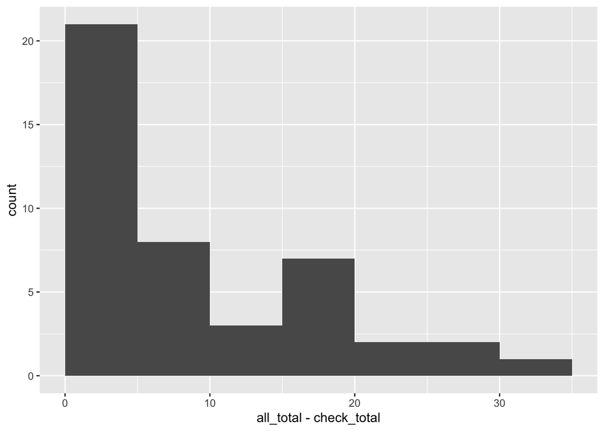

```r
awt %>%
  filter(all_total != check_total) %>%
ggplot(aes(x=all_total - check_total)) +
  geom_histogram(boundary=0,binwidth=5)
```

#### Let’s consider another way to check the totals (`all_total`) using `purrr::pmap_dbl()`.

```r
awt <- awt %>%
  ## add day of the week
  mutate(wday = wday(date, label=TRUE)) %>%
  ## check total obvious way (see previous lecture)
  mutate(check_total = all_n_0_15 +
            all_n_16_30 +
            all_n_31_45 +
            all_n_46_60 +
            all_n_61_90 +
            all_n_91_120 +
            all_n_120_plus +
            all_excluded) %>%
  ## check total in a new way using purrr::pmap_dbl()
  ## pmap_dbl here takes a data frame as its first argument
  ##   and then applies the function row-wise to its elements, we will use the `sum()` function
  ## select() supplies the data frame
  ## because we do not pipe into select here directly (we're inside of a pipe into mutate),
  ##   we need to specify the input to select (we need to note which variables we want to sum over)
  ##   The '.' represents the object that was piped into mutate
  ##   To this we select the columns that contain "_n_" and 'all_excluded'
  ## the row sums of this selected sub-data frame are saved as a new
  ##   variable named check_total2
  mutate(check_total2 =
           pmap_dbl(select(.,contains("_n_"),all_excluded),sum)) %>%
  select(airport,terminal,date,month,wday,everything())

## Verify that the check sums match each other
awt %>%
  select(check_total,check_total2) %>% # two variables totaling the passenger counts
  mutate(diff = check_total - check_total2) %>% # take the difference
  summarize(min = min(diff),
            max = max(diff),
            ndiff = sum(diff != 0))
```

```
## # A tibble: 1 x 3
##     min   max ndiff
##   <dbl> <dbl> <int>
## 1     0     0     0
```

```r
## Note that there are no differences

## Compare check_total to all_total
check_total_mismatch <- awt %>%
  filter(check_total != all_total) %>%
  mutate(error = all_total - check_total) %>%
  select(airport,date,hour,all_total,check_total,error,everything())

print(paste0(nrow(check_total_mismatch), " observations out of ", nrow(awt), " have an error, or ", round(nrow(check_total_mismatch)/nrow(awt)*100, 2), " %"))
```

```
## [1] "44 observations out of 72089 have an error, or 0.06 %"
```

```r
##---will use check_total instead of all_total, but likely will not matter.
```

#### Summary of findings

The data do not contain any observations on May 8, 2018.

The errors in `all_total` all involve a few counts with totals larger than the checked total (`check_total`). We can use `check_total` as the actual value, but this assumes the individual column counts are correct. Some correction or ignoring the issue is not likely to make much difference in major questions.

### Associations

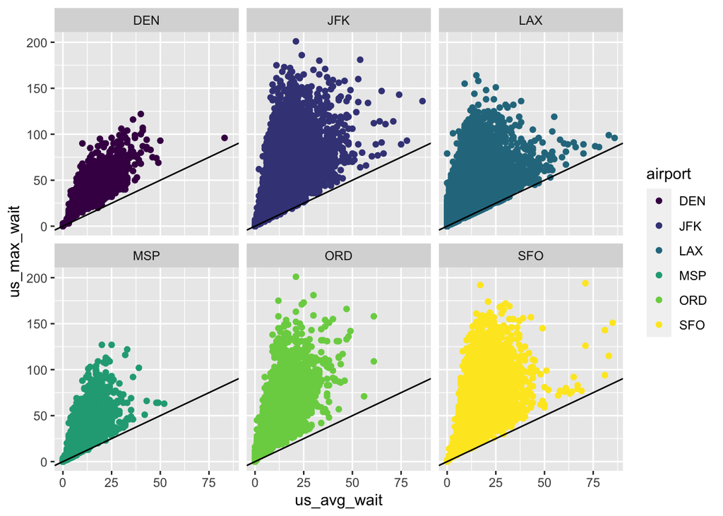

```r
ggplot(awt, aes(x=us_avg_wait,y=us_max_wait,color=airport)) +
  geom_point() +
  geom_abline(intercept=0,slope=1) +
  facet_wrap(~airport)
```

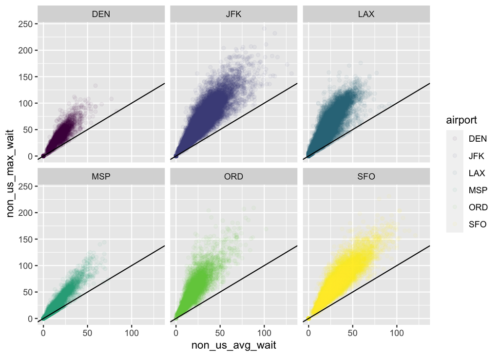

```r
ggplot(awt, aes(x=non_us_avg_wait,y=non_us_max_wait,color=airport)) +
  geom_point(alpha=.05) +
  geom_abline(intercept=0,slope=1) +
  facet_wrap(~airport)
```

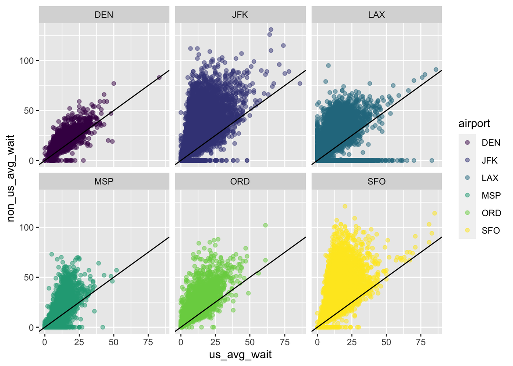

```r
ggplot(awt, aes(x=us_avg_wait, y=non_us_avg_wait, color=airport)) +
  geom_point(alpha = 0.5) +
  geom_abline(intercept=0,slope=1) +
  facet_wrap(~airport)
```

```r
## It looks like there are some times where there were few or no non-US international travelers
awt %>%
  filter(non_us_avg_wait == 0)
```

```
## # A tibble: 4,241 x 25
##    airport terminal date       month wday  hour  us_avg_wait us_max_wait
##    <chr>   <chr>    <date>     <ord> <ord> <chr>       <dbl>       <dbl>
##  1 DEN     Interna… 2018-01-02 Jan   Tue   1600…          16          24
##  2 DEN     Interna… 2018-01-06 Jan   Sat   1900…          15          22
##  3 DEN     Interna… 2018-01-12 Jan   Fri   1900…          19          29
##  4 DEN     Interna… 2018-01-13 Jan   Sat   1900…          15          21
##  5 DEN     Interna… 2018-01-16 Jan   Tue   1100…           0           0
##  6 DEN     Interna… 2018-01-21 Jan   Sun   1900…           5          14
##  7 DEN     Interna… 2018-01-23 Jan   Tue   1800…          17          28
##  8 DEN     Interna… 2018-01-27 Jan   Sat   1800…           7          14
##  9 DEN     Interna… 2018-02-01 Feb   Thu   1900…          16          22
## 10 DEN     Interna… 2018-02-14 Feb   Wed   1900…          10          16
## # … with 4,231 more rows, and 17 more variables: non_us_avg_wait <dbl>,
## #   non_us_max_wait <dbl>, all_avg_wait <dbl>, all_max_wait <dbl>,
## #   all_n_0_15 <dbl>, all_n_16_30 <dbl>, all_n_31_45 <dbl>, all_n_46_60 <dbl>,
## #   all_n_61_90 <dbl>, all_n_91_120 <dbl>, all_n_120_plus <dbl>,
## #   all_excluded <dbl>, all_total <dbl>, all_flights <dbl>, all_booths <dbl>,
## #   check_total <dbl>, check_total2 <dbl>
```

## Some questions to consider

1. Are some airports more efficient that than others in terms of average wait time?
   - Are some airports more efficient in the number of people served by hour per available booth?
2. Are some months busier than others?
   - Are some days of the week busier than others?
   - Are some times during the day busier than others?
3. How does the proportion of people who get through customs in less than 30 minutes depend on other factors?

# Lecture: Airport efficiency

> Are some airports more efficient than others in terms of average wait time?

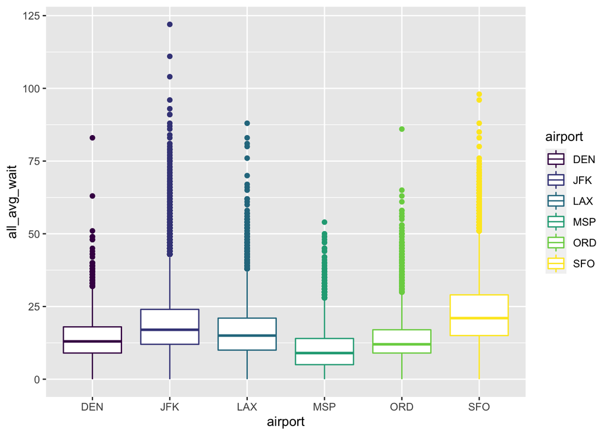

```r
ggplot(awt, aes(x=airport, y=all_avg_wait, color=airport)) +
  geom_boxplot()
```

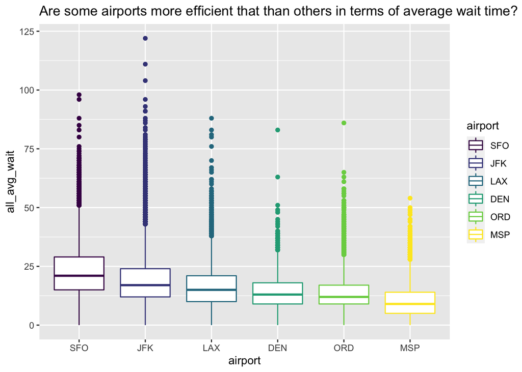

```r
awt %>%
  mutate(airport = reorder(airport,-all_avg_wait, FUN=median)) %>%
  #`airport` as factor with levels ordered according to -all_avg_wait and FUN value
  ggplot(aes(x=airport, y=all_avg_wait, color=airport)) +
  geom_boxplot() +
  ggtitle("Are some airports more efficient that than others in terms of average wait time?")
```

> Are some airports more efficient in the number of people served by hour per available booth?

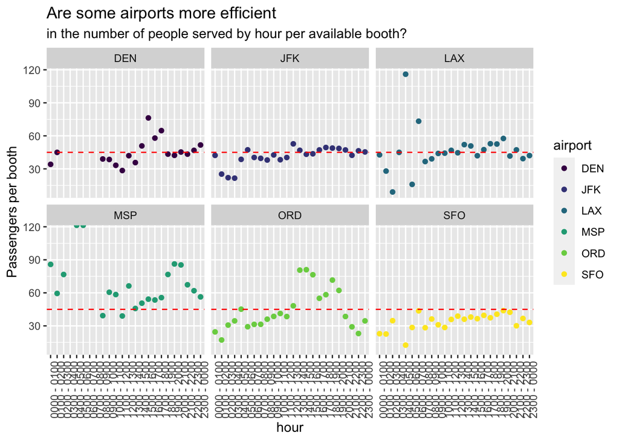

```r
awt %>%
  group_by(airport, hour) %>%
  summarize(total = sum(check_total), booth_total=sum(all_booths)) %>%
  mutate(per_booth=round(total/booth_total,2)) %>%
  select(-total, -booth_total) %>%
  ggplot(aes(hour, per_booth, color=airport)) +
  geom_point() +
  geom_hline(yintercept=45, linetype="dashed",color="red") +
  facet_wrap(~airport) +
  theme(axis.text.x = element_text(angle = 90, hjust = 1)) +
  ylab("Passengers per booth") +
  ggtitle("Are some airports more efficient",
          subtitle="in the number of people served by hour per available booth?")
```

There do appear to be differences between the efficiency (in terms of passengers per booth per hour) among the airports. For example, MSP seems to be more efficient (in the noted sense) regularly serving more than 45 passengers per booth per hour. SFO seems to serve fewer than 45 passengers per booth per hour most of the time.

# Lecture: Busy times

> Are some months busier than others?

Count the total number of passengers by month and sort.

```r
awt %>%
  group_by(month) %>%
  summarize(total = sum(check_total)) %>%
  arrange(desc(total))
```

```
## # A tibble: 12 x 2
##    month   total
##    <ord>   <dbl>
##  1 Jul   4313556
##  2 Aug   4243989
##  3 Jun   3737703
##  4 Sep   3510685
##  5 Apr   3475030
##  6 Oct   3393282
##  7 Mar   3356425
##  8 May   3337989
##  9 Jan   3249648
## 10 Dec   3145717
## 11 Nov   3020607
## 12 Feb   2646150
```

The previous summary is affected by different numbers of days in each month. Calculate the average daily rate of passengers by month. (Recall that May has only 30 observations.)

Key idea here is to first summarize by month and day, and then by month, in order to get the total number of passengers in each month and the number of days in each month.

```r
busy_months <- awt %>%
  mutate(day = day(date)) %>%
  group_by(month,day) %>%
  summarize(total = sum(check_total)) %>%
  group_by(month) %>%
  summarize(n=n(), total = sum(total), daily = total/n) %>%
  arrange(desc(daily))
busy_months
```

```
## # A tibble: 12 x 4
##    month     n   total   daily
##    <ord> <int>   <dbl>   <dbl>
##  1 Jul      31 4313556 139147.
##  2 Aug      31 4243989 136903.
##  3 Jun      30 3737703 124590.
##  4 Sep      30 3510685 117023.
##  5 Apr      30 3475030 115834.
##  6 May      30 3337989 111266.
##  7 Oct      31 3393282 109461.
##  8 Mar      31 3356425 108272.
##  9 Jan      31 3249648 104827.
## 10 Dec      31 3145717 101475.
## 11 Nov      30 3020607 100687.
## 12 Feb      28 2646150  94505.
```

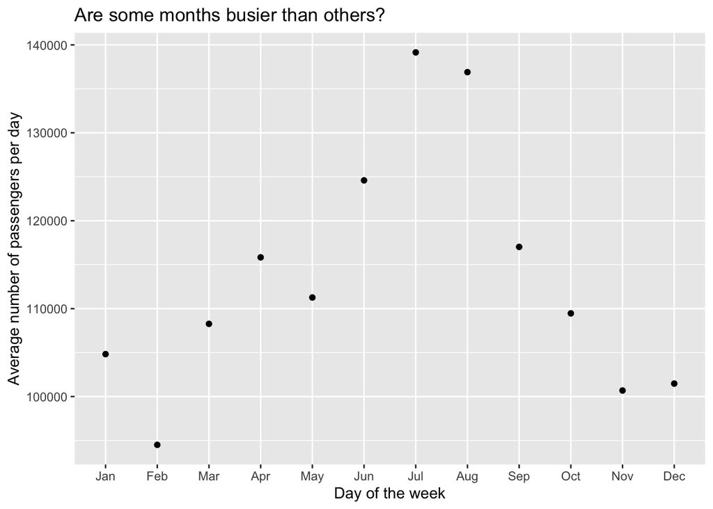

```r
ggplot(busy_months, aes(month, daily)) +
  geom_point() +
  xlab("Day of the week") +
  ylab("Average number of passengers per day") +
  ggtitle("Are some months busier than others?")
```

It looks like the summer months (July, August, June) are the busiest in terms of number of passengers traveling per day for the airports in our data.

> Are some days of the week busier than others?

```r
# This approach is wrong - can you see why?
# Look at the displayed `total` for each day...were there 6,544,008 Saturdays in 2018?!
# This is count is based on the rows in the table with wday == "Sat", not the number
# of Saturdays in 2018.
awt %>%
  group_by(wday) %>%
  summarize(total = sum(check_total), n = n()) %>%
  mutate(daily=round(total/n,2)) %>%
  arrange(desc(daily))
```

```
## # A tibble: 7 x 4
##   wday    total     n daily
##   <ord>   <dbl> <int> <dbl>
## 1 Sat   6544008 10680  613.
## 2 Sun   6366166 10616  600.
## 3 Mon   6121185 10494  583.
## 4 Fri   5833778 10236  570.
## 5 Thu   5628647 10072  559.
## 6 Wed   5532497 10040  551.
## 7 Tue   5404500  9951  543.
```

```r
# We first need to count the number of each day of the week in 2018
busy_wdays <- awt %>%
  group_by(date, wday) %>%
  summarize(total = sum(check_total)) %>%
  group_by(wday) %>%
  summarize(n=n(), total = sum(total))  %>%
  mutate(daily=round(total/n,2)) %>%
  arrange(desc(daily))
busy_wdays
```

```
## # A tibble: 7 x 4
##   wday      n   total   daily
##   <ord> <int>   <dbl>   <dbl>
## 1 Sat      52 6544008 125846.
## 2 Sun      52 6366166 122426.
## 3 Mon      53 6121185 115494.
## 4 Fri      52 5833778 112188.
## 5 Thu      52 5628647 108243.
## 6 Wed      52 5532497 106394.
## 7 Tue      51 5404500 105971.
```

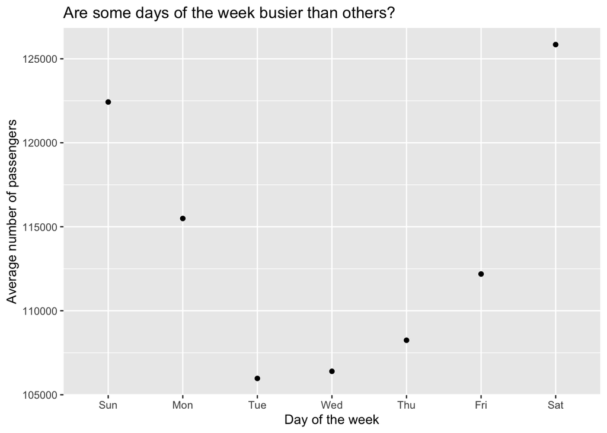

```r
ggplot(busy_wdays, aes(wday, daily)) +
  geom_point() +
  xlab("Day of the week") +
  ylab("Average number of passengers") +
  ggtitle("Are some days of the week busier than others?")
```

> Are some times during the day busier than others?

```r
busy_times <- awt %>%
  group_by(date, hour) %>%
  summarize(total = sum(check_total)) %>%
  group_by(hour) %>%
  summarize(n=n(), total = sum(total))  %>%
  mutate(hourly=round(total/n,2)) %>%
  arrange(desc(hourly))
busy_times
```

```
## # A tibble: 24 x 4
##    hour            n   total hourly
##    <chr>       <int>   <dbl>  <dbl>
##  1 1300 - 1400   364 3378614  9282.
##  2 1400 - 1500   364 3187415  8757.
##  3 1500 - 1600   364 3177401  8729.
##  4 1200 - 1300   364 3092218  8495.
##  5 1600 - 1700   364 3043461  8361.
##  6 1700 - 1800   364 2913956  8005.
##  7 1800 - 1900   364 2799314  7690.
##  8 1900 - 2000   364 2700282  7418.
##  9 1100 - 1200   364 2165588  5949.
## 10 2000 - 2100   364 2001425  5498.
## # … with 14 more rows
```

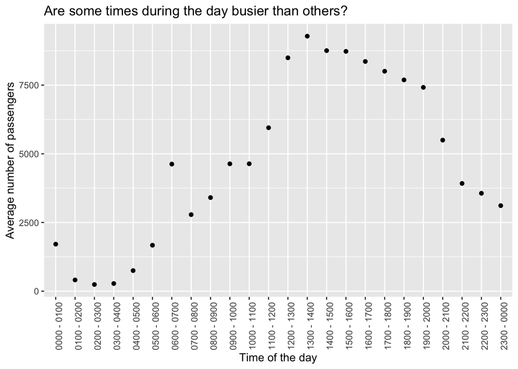

```r
ggplot(busy_times, aes(hour, hourly)) +
  geom_point() +
  theme(axis.text.x = element_text(angle = 90, hjust = 1))  +
  xlab("Time of the day") +
  ylab("Average number of passengers") +
  ggtitle("Are some times during the day busier than others?")
```

# Lecture: Getting through customs quickly

> How does the proportion of people who get through customs in less than 30 minutes depend on other factors?

```r
## Add columns for proportion less than 30 minutes and proportion more than an hour
awt <- awt %>%
  mutate(p_less_30 = (all_n_0_15 + all_n_16_30) / check_total,
         p_more_60 = (all_n_61_90 + all_n_91_120 + all_n_120_plus) / check_total)
```

#### Factor: Airport

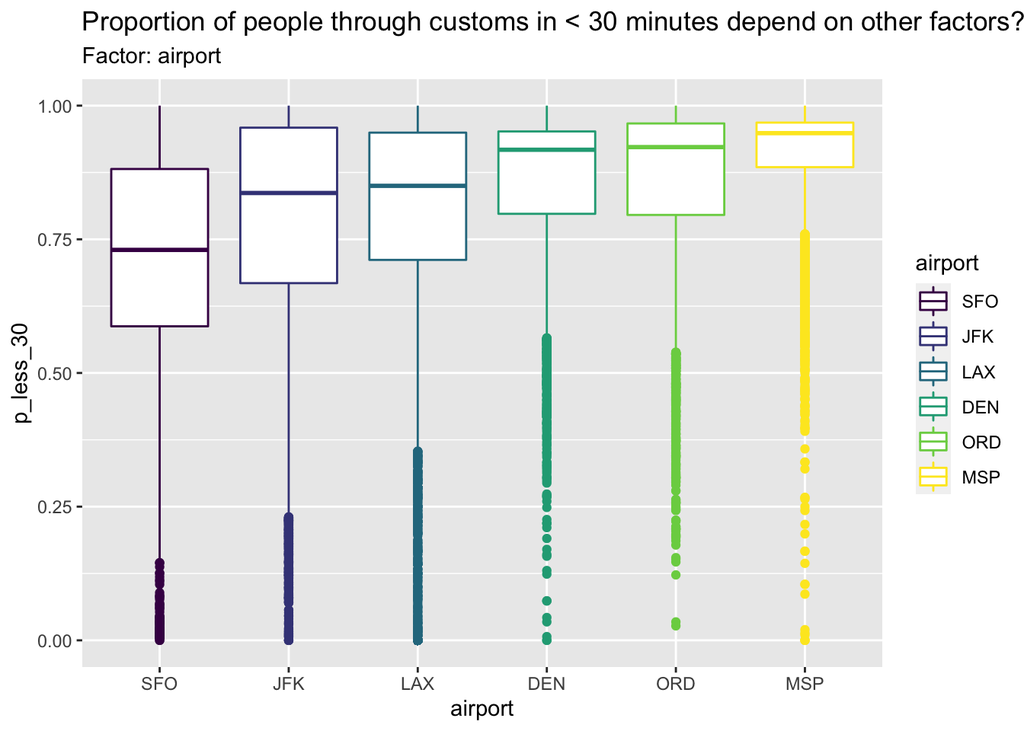

```r
awt %>%
  mutate(airport = reorder(airport,p_less_30,FUN=median)) %>%
ggplot(aes(x=airport,y=p_less_30,color=airport)) +
  geom_boxplot() +
  ggtitle("Proportion of people through customs in < 30 minutes depend on other factors?",
          subtitle = "Factor: airport")
```

#### Factor: Hour

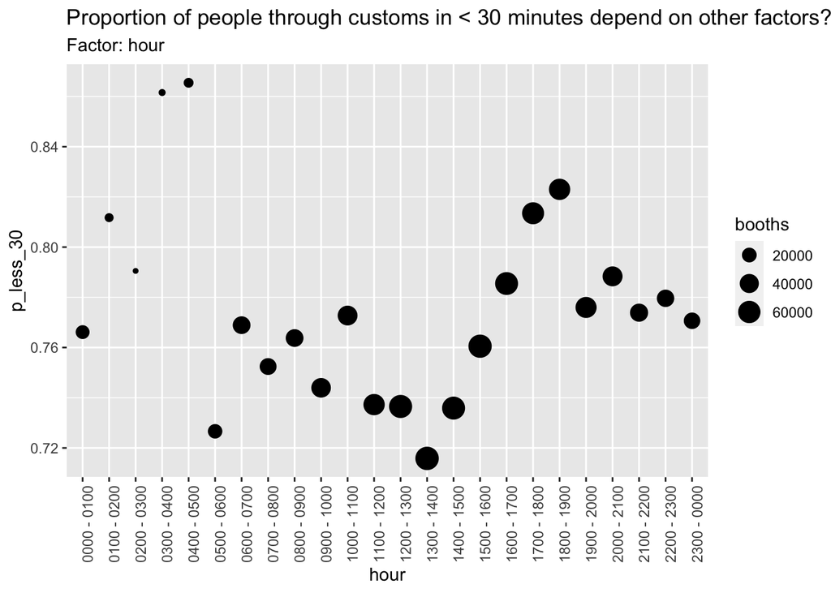

```r
## Fraction of passengers per hour that go through in < 30 minutes
awt %>%
  group_by(hour) %>%
  summarize(total = sum(check_total),
          n_less_30 = sum(all_n_0_15) + sum(all_n_16_30),
          p_less_30 = n_less_30 / total,
          booths = sum(all_booths)) %>%
  ggplot(aes(hour,p_less_30, size = booths)) +
  geom_point() +
  theme(axis.text.x = element_text(angle = 90, hjust = 1)) +
  ggtitle("Proportion of people through customs in < 30 minutes depend on other factors?",
          subtitle = "Factor: hour")
```

#### Factor: Airport and Hour

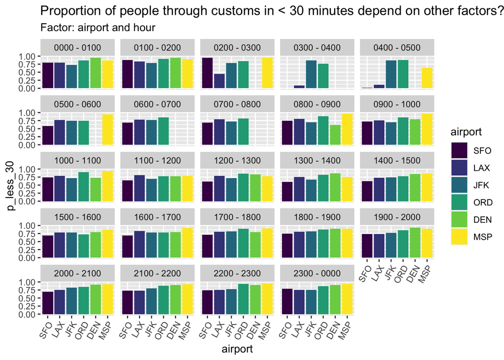

```r
## Fraction of passengers per airport and per hour that go through in < 30 minutes
awt %>%
  group_by(airport,hour) %>%
  summarize(total = sum(check_total),
            n_less_30 = sum(all_n_0_15) + sum(all_n_16_30),
            p_less_30 = n_less_30 / total,
            booths = sum(all_booths)) %>%
  ungroup() %>% ## airport is a grouping variable and cannot be mutated
  mutate(airport = reorder(airport,p_less_30,FUN=mean)) %>%
  ggplot(aes(x=airport, y=p_less_30,fill=airport)) +
  geom_col() +
  facet_wrap(~hour) +
  theme(axis.text.x = element_text(angle = 60, hjust = 1)) +
  ggtitle("Proportion of people through customs in < 30 minutes depend on other factors?",
          subtitle = "Factor: airport and hour")
```

```r
# It looks like some of the airports do not have passengers in certain time windows
# Is that correct?
awt %>%
  filter(airport=="MSP") %>%
  group_by(hour) %>%
  summarize(tot = sum(check_total))
```

```
## # A tibble: 21 x 2
##    hour           tot
##    <chr>        <dbl>
##  1 0000 - 0100   8844
##  2 0100 - 0200    892
##  3 0200 - 0300    460
##  4 0400 - 0500     11
##  5 0500 - 0600     35
##  6 0800 - 0900  18578
##  7 0900 - 1000  10108
##  8 1000 - 1100  10580
##  9 1100 - 1200  51759
## 10 1200 - 1300 169542
## # … with 11 more rows
```

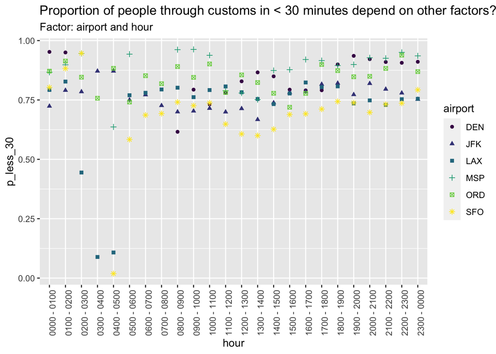

```r
## Let's try a scatterplot of the same information as the previous graphic
## -> which is easier to interpret?
## Fraction of passengers per airport and per hour that go through in < 30 minutes
awt %>%
  group_by(airport,hour) %>%
  summarize(total = sum(check_total),
            n_less_30 = sum(all_n_0_15) + sum(all_n_16_30),
            p_less_30 = n_less_30 / total,
            booths = sum(all_booths)) %>%
  ggplot(aes(x=hour, y=p_less_30,color=airport, shape=airport)) +
  geom_point() +
  theme(axis.text.x = element_text(angle = 90, hjust = 1)) +
  ggtitle("Proportion of people through customs in < 30 minutes depend on other factors?",
          subtitle = "Factor: airport and hour")
```

#### Factor: Number of Booths and Hour

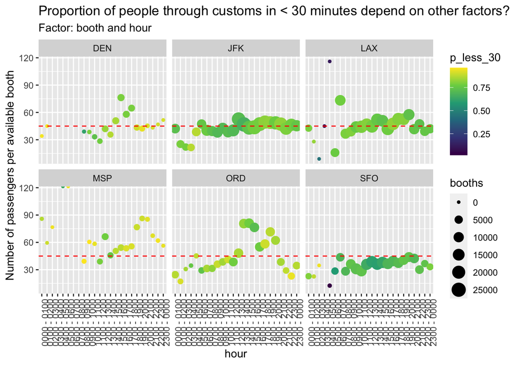

```r
# Look at passengers per booth vs. hour
# Color based on proportion who wait less than 30 minutes
# Consider size based on the number of booths open
awt %>%
  group_by(airport,hour) %>%
  summarize(total = sum(check_total),
            n_less_30 = sum(all_n_0_15) + sum(all_n_16_30),
            p_less_30 = n_less_30 / total,
            booths = sum(all_booths)) %>%
  mutate(passenger_per_booth = total/booths) %>%
  ggplot(aes(hour,passenger_per_booth, color=p_less_30, size = booths)) +
  geom_point() +
  geom_hline(yintercept=45, color="red", linetype="dashed") +
  facet_wrap(~airport) +
  ylab("Number of passengers per available booth") +
  theme(axis.text.x = element_text(angle = 90, hjust = 1)) +
  ggtitle("Proportion of people through customs in < 30 minutes depend on other factors?",
          subtitle = "Factor: booth and hour")
```

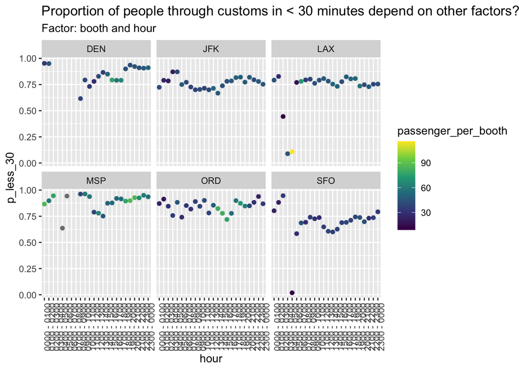

```r
# Look at proportion who wait less than 30 minutes vs. hour
# Color based on proportion number of passengers per booth
awt %>%
  group_by(airport,hour) %>%
  summarize(total = sum(check_total),
            n_less_30 = sum(all_n_0_15) + sum(all_n_16_30),
            p_less_30 = n_less_30 / total,
            booths = sum(all_booths)) %>%
  mutate(passenger_per_booth = total/booths) %>%
  ggplot(aes(hour,p_less_30, color=passenger_per_booth)) +
  geom_point() +
  facet_wrap(~airport) +
  theme(axis.text.x = element_text(angle = 90, hjust = 1)) +
  ggtitle("Proportion of people through customs in < 30 minutes depend on other factors?",
          subtitle = "Factor: booth and hour")
```

> Can you think of your own questions to address with this data set?